# Tarea

Karla Reyo, Luizet Castro y Patricia Trujillo

25 de febrero de 2019

## Descripción

El problema consiste en predecir el precio final de cada casa para lo cual tenemos los siguientes datos:

- train.csv - el conjunto de entrenamiento
- test.csv - el conjunto de prueba
- data_description.txt - las descripción completa de las columnas
- sample_submission.csv - un benchmark de una regresi?n lineal

## Diccionario de datos

| Variable | Description |
| --- | --- |
| SalePrice | The property’s sale price in dollars. This is the target variable that you’re trying to predict |
| MSSubClass | The building class |
| MSZoning | The general zoning classification |
| LotFrontage | Linear feet of street connected to property |
| LotArea | Lot size in square feet |
| Street | Type of road access |
| Alley | Type of alley access |
| LotShape | General shape of property |
| LandContour | Flatness of the property |
| Utilities | Type of utilities available |
| LotConfig | Lot configuration |
| LandSlope | Slope of property |
| Neighborhood | Physical locations within Ames city limits |
| Condition1 | Proximity to main road or railroad |
| Condition2 | Proximity to main road or railroad (if a second is present) |
| BldgType | Type of dwelling |
| HouseStyle | Style of dwelling |
| OverallQual | Overall material and finish quality |
| OverallCond | Overall condition rating |
| YearBuilt | Original construction date |
| YearRemodAdd | Remodel date |
| RoofStyle | Type of roof |
| RoofMatl | Roof material |
| Exterior1st | Exterior covering on house |
| Exterior2nd | Exterior covering on house (if more than one material) |
| MasVnrType | Masonry veneer type |
| MasVnrArea | Masonry veneer area in square feet |
| ExterQual | Exterior material quality |
| ExterCond | Present condition of the material on the exterior |
| Foundation | Type of foundation |
| BsmtQual | Height of the basement |
| BsmtCond | General condition of the basement |
| BsmtExposure | Walkout or garden level basement walls |
| BsmtFinType1 | Quality of basement finished area |
| BsmtFinSF1 | Type 1 finished square feet |
| BsmtFinType2 | Quality of second finished area (if present) |
| BsmtFinSF2 | Type 2 finished square feet |
| BsmtUnfSF | Unfinished square feet of basement area |
| TotalBsmtSF | Total square feet of basement area |
| Heating | Type of heating |
| HeatingQC | Heating quality and condition |
| CentralAir | Central air conditioning |
| Electrical | Electrical system |
| 1stFlrSF | First Floor square feet |
| 2ndFlrSF | Second floor square feet |
| LowQualFinSF | Low quality finished square feet (all floors) |
| GrLivArea | Above grade (ground) living area square feet |
| BsmtFullBath | Basement full bathrooms |
| BsmtHalfBath | Basement half bathrooms |
| FullBath | Full bathrooms above grade |
| HalfBath | Half baths above grade |
| Bedroom | Number of bedrooms above basement level |
| Kitchen | Number of kitchens |
| KitchenQual | Kitchen quality |
| TotRmsAbvGrd | Total rooms above grade (does not include bathrooms) |
| Functional | Home functionality rating |
| Fireplaces | Number of fireplaces |
| FireplaceQu | Fireplace quality |
| GarageType | Garage location |
| GarageYrBlt | Year garage was built |
| GarageFinish | Interior finish of the garage |
| GarageCars | Size of garage in car capacity |
| GarageArea | Size of garage in square feet |
| GarageQual | Garage quality |
| GarageCond | Garage condition |
| PavedDrive | Paved driveway |
| WoodDeckSF | Wood deck area in square feet |
| OpenPorchSF | Open porch area in square feet |
| EnclosedPorch | Enclosed porch area in square feet |
| 3SsnPorch | Three season porch area in square feet |
| ScreenPorch | Screen porch area in square feet |
| PoolArea | Pool area in square feet |
| PoolQC | Pool quality |
| Fence | Fence quality |
| MiscFeature | Miscellaneous feature not covered in other categories |
| MiscVal | $Value of miscellaneous feature |
| MoSold | Month Sold |
| YrSold | Year Sold |
| SaleType | Type of sale |
| SaleCondition | Condition of sale |

## Análisis exploratorio de datos

```
## El conjunto de datos cuenta con  81  columnas y  1460  observaciones
```

```
## La tabla se ve como sigue:
```

```
## 'data.frame':    1460 obs. of  11 variables:
##  $ Id         : int  1 2 3 4 5 6 7 8 9 10 ...
##  $ MSSubClass : int  60 20 60 70 60 50 20 60 50 190 ...
##  $ MSZoning   : chr  "RL" "RL" "RL" "RL" ...
##  $ LotFrontage: int  65 80 68 60 84 85 75 NA 51 50 ...
##  $ LotArea    : int  8450 9600 11250 9550 14260 14115 10084 10382 6120 7420 ...
##  $ Street     : chr  "Pave" "Pave" "Pave" "Pave" ...
##  $ Alley      : chr  NA NA NA NA ...
##  $ LotShape   : chr  "Reg" "Reg" "IR1" "IR1" ...
##  $ LandContour: chr  "Lvl" "Lvl" "Lvl" "Lvl" ...
##  $ Utilities  : chr  "AllPub" "AllPub" "AllPub" "AllPub" ...
##  $ SalePrice  : int  208500 181500 223500 140000 250000 143000 307000 200000 129900 118000 ...
```

Ahora veamos la distribución de la variable objetivo

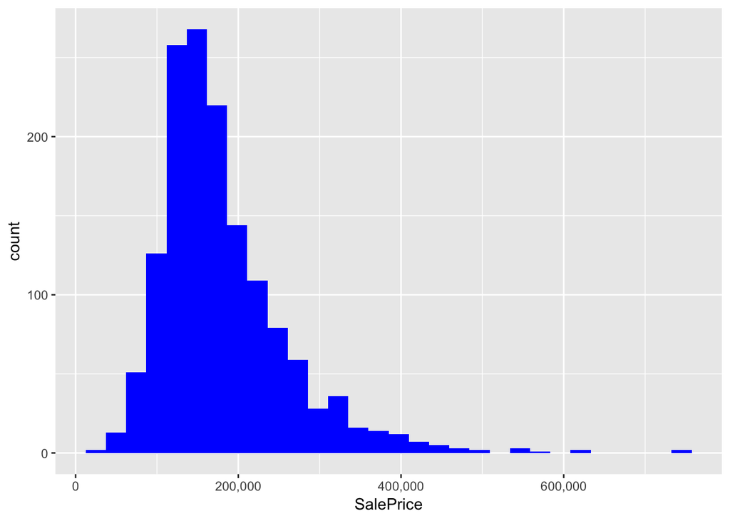

```
##    Min. 1st Qu.  Median    Mean 3rd Qu.    Max.
##   34900  129975  163000  180921  214000  755000
```

## Limpieza de datos

```
## Hay 19 columnas con valores missing en el conjunto de entrenamiento
```

```
## El número de missings por columna es:
```

```
##       PoolQC  MiscFeature        Alley        Fence  FireplaceQu
##         1453         1406         1369         1179          690
##  LotFrontage   GarageType  GarageYrBlt GarageFinish   GarageQual
##          259           81           81           81           81
##   GarageCond BsmtExposure BsmtFinType2     BsmtQual     BsmtCond
##           81           38           38           37           37
## BsmtFinType1   MasVnrType   MasVnrArea   Electrical
##           37            8            8            1
```

```
## Hay 33 columnas con valores missing en el conjunto de prueba
```

```
## El número de missings por columna es:
```

```
##       PoolQC  MiscFeature        Alley        Fence  FireplaceQu
##         1456         1408         1352         1169          730
##  LotFrontage  GarageYrBlt GarageFinish   GarageQual   GarageCond
##          227           78           78           78           78
##   GarageType     BsmtCond     BsmtQual BsmtExposure BsmtFinType1
##           76           45           44           44           42
## BsmtFinType2   MasVnrType   MasVnrArea     MSZoning    Utilities
##           42           16           15            4            2
## BsmtFullBath BsmtHalfBath   Functional  Exterior1st  Exterior2nd
##            2            2            2            1            1
##   BsmtFinSF1   BsmtFinSF2    BsmtUnfSF  TotalBsmtSF  KitchenQual
##            1            1            1            1            1
##   GarageCars   GarageArea     SaleType
##            1            1            1
```

Hicimos un análisis e imputaremos por tipo de variable

```
## Después de imputar tenemos 0 columnas con valores missing
```

```
## Hay 38 variables num?ricas
```

```
## Haciendo un análisis de la correlación entre variables númericas, para aquellas que estan altamente correlacionadas con la variable objetivo (SalePrice) podemo ver que existe un problema de multicolinealidad como se observa en la siguiente gráfica.
```

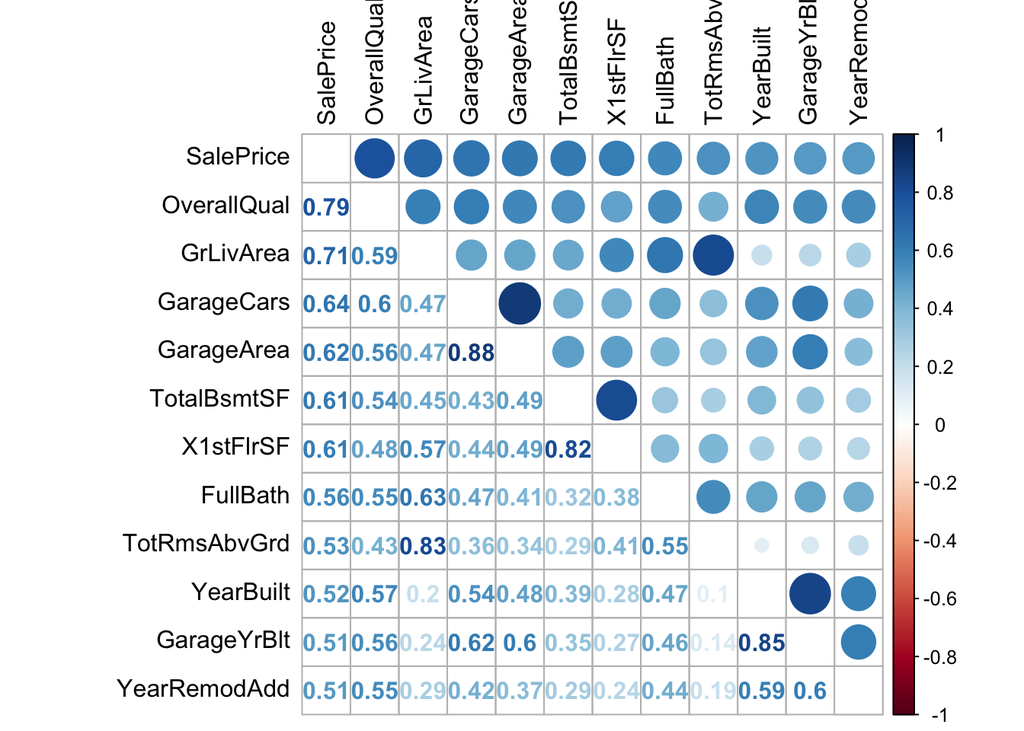

```
## Tenemos 43 columnas con variables categóricas
```

Podemos convertir las variables categoricas a factores

O transformarla en dummies

```
## Al final, al crear variables dummies, tenemos un nuevo conjunto de datos con 305
```

## Reducción de variables

Haremos reducción de variables con un random forest con ambos escenarios, cuando tenemos factores y cuando tenemos variables dummies.

### Caso con factores

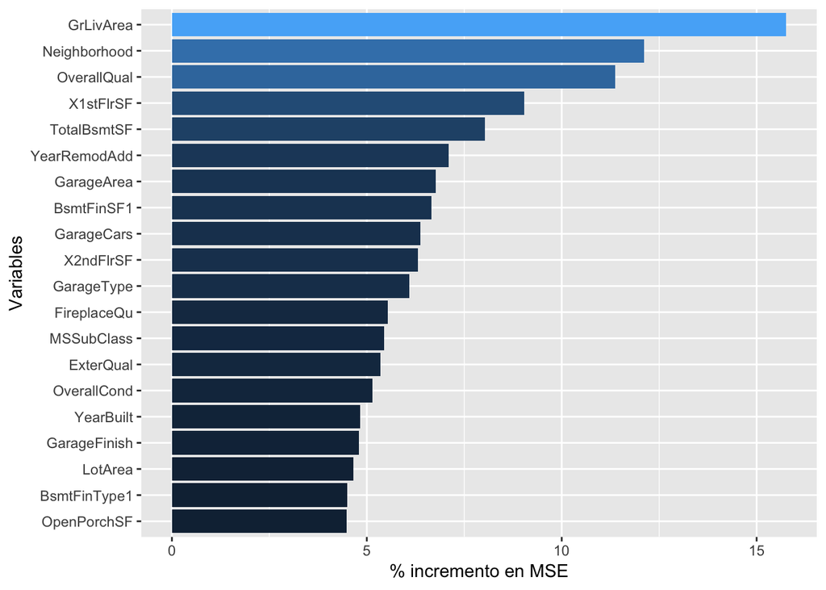

### Caso con variables dummies

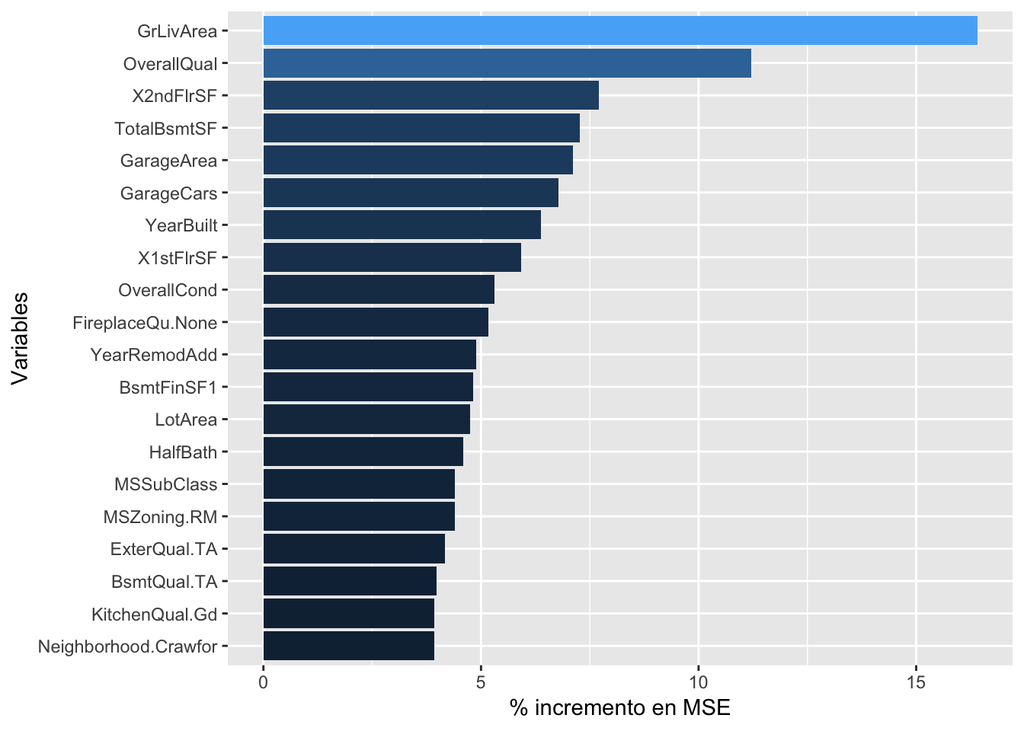

## Feature Engineering

Comenzamos seleccionando las variables en comun entre las variables más importantes de cada random forest

```
## Tenemos 13 variables en comun que son las siguientes
```

```
##  [1] "GrLivArea"    "OverallQual"  "X1stFlrSF"    "TotalBsmtSF"
##  [5] "YearRemodAdd" "GarageArea"   "BsmtFinSF1"   "GarageCars"
##  [9] "X2ndFlrSF"    "MSSubClass"   "OverallCond"  "YearBuilt"
## [13] "LotArea"
```

Es posible generar más features con las variables que no están en la intersección para tener un análisis más completo sin embargo, los dejaremos fuera de nuestro trabajo.

## Modelos

Realizamos varios modelos para estimar el precio de venta de las casas dadas las variables seleccionadas. Utilizamos una regresión lineal, un random forest y un gradient boosting machine.

```
## Realizamos diferentes modelos con los siguientes parámetros para rf
```

```
##   mtry
## 1    2
## 2    4
## 3    6
## 4    8
## 5   10
```

```
## Y para gbm
```

```
##   interaction.depth n.trees shrinkage n.minobsinnode
## 1                 1     100      0.01             20
## 2                 2     100      0.01             20
## 3                 1     150      0.01             20
## 4                 2     150      0.01             20
## 5                 1     100      0.10             20
## 6                 2     100      0.10             20
## 7                 1     150      0.10             20
## 8                 2     150      0.10             20
```

```
## También realizamos una validación para conocer cual es el mejor modelo sin embargo, en ningún caso pudimos rechazar la hipótesis nula como se ve en el siguiente resultado.
```

```
##
##  One Sample t-test
##
## data:  x
## t = -0.31723, df = 9, p-value = 0.7583
## alternative hypothesis: true mean is not equal to 0
## 95 percent confidence interval:
##  -9332.466  7036.944
## sample estimates:
## mean of x
## -1147.761
```

```
## A continuación encontramos la comparación de los modelos:
```

```
##
## Call:
## summary.resamples(object = res)
##
## Models: lm, rf, gbm
## Number of resamples: 10
##
## MAE
##         Min.  1st Qu.   Median     Mean  3rd Qu.     Max. NA's
## lm  18413.96 20126.83 22197.57 22074.43 22857.26 26396.89    0
## rf  15050.62 16264.00 16739.93 17220.37 17791.04 21660.39    0
## gbm 15162.22 16533.28 17866.33 18275.25 19577.94 22407.60    0
##
## RMSE
##         Min.  1st Qu.   Median     Mean  3rd Qu.     Max. NA's
## lm  25956.13 28816.59 32336.21 36125.25 39407.70 62941.60    0
## rf  21965.88 23986.91 26609.77 28926.86 29347.66 43390.41    0
## gbm 22497.24 24368.84 26860.45 30074.62 31924.98 53449.24    0
##
## Rsquared
##          Min.   1st Qu.    Median      Mean   3rd Qu.      Max. NA's
## lm  0.5589715 0.8080594 0.8387781 0.8016138 0.8513099 0.8687147    0
## rf  0.7724237 0.8426893 0.8832926 0.8706890 0.8974014 0.9284787    0
## gbm 0.6634888 0.8612265 0.8729779 0.8615962 0.9078512 0.9213652    0
```

```
## Basado en las métricas anteriores, elegimos el Rf como mejor modelo. Y tiene los siguientes parámetros
```

```
##   mtry
## 2    4
```

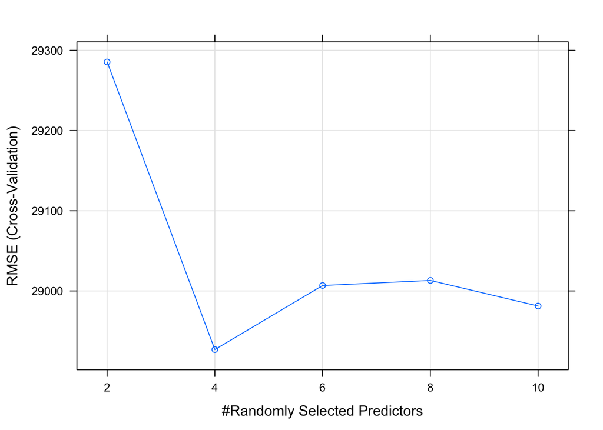

[output not shown]

```
##        1        2        3        4        5        6
## 126654.9 159136.3 178157.3 181831.5 197374.6 184377.7
```